# SWNE analysis of hematopoiesis chromatin accessibility

Yan Wu

4/26/2019

This is a walkthrough on how to use SWNE to visualize a hematopoiesis chromatin accessibility trajectory from [Buenrostro et al, 2018](https://doi.org/10.1016/j.cell.2018.03.074), starting from a cisTopic object that has already been processed using the cisTopic pipeline. That data can be downloaded here.

Before we start, you’ll need some additional packages for TF binding site annotation and analysis.

```r
if (!requireNamespace("BiocManager", quietly = TRUE))
    install.packages("BiocManager")
BiocManager::install("motifmatchr", version = "3.8")
BiocManager::install("BSgenome.Hsapiens.UCSC.hg19", version = "3.8")
BiocManager::install("TxDb.Hsapiens.UCSC.hg19.knownGene", version = "3.8")
BiocManager::install("org.Hs.eg.db", version = "3.8")
BiocManager::install("SummarizedExperiment", version = "3.8")
BiocManager::install("TFBSTools", version = "3.8")
BiocManager::install("chromVAR")

if(!require(devtools)){
  install.packages("devtools") # If not already installed;
}
devtools::install_github("GreenleafLab/chromVARmotifs")
```

Load the required libraries and data. The data has already been preprocessed with using their standard pipeline.

```r
library(cisTopic)
library(swne)
library(chromVAR)
library(chromVARmotifs)
library(motifmatchr)
library(SummarizedExperiment)
library(org.Hs.eg.db)
library(TxDb.Hsapiens.UCSC.hg19.knownGene)
library(BSgenome.Hsapiens.UCSC.hg19)
library(TFBSTools)

load("~/swne/Data/scATAC_hemato_cisTopic.RData")
```

We can run SWNE directly on the cisTopicObject. Increasing `snn.k` and decreasing `snn.exp` will pull more cells onto the primary axes of variation (in this case the monocyte/lymphoid and erythrocyte trajectories) at the expense of some cell type separation.

```r
## Run SWNE
swne.emb <- RunSWNE(cisTopicObject, alpha.ex = 1.25, snn.exp = 1,
                    n_pull = 3, snn.k = 30, prune.SNN = 1/20)
```

```
## Initial stress        : 0.13224
## stress after  10 iters: 0.04034, magic = 0.461
## stress after  20 iters: 0.03158, magic = 0.500
## stress after  30 iters: 0.03087, magic = 0.500
## stress after  40 iters: 0.03064, magic = 0.500
## stress after  50 iters: 0.03052, magic = 0.500
## stress after  60 iters: 0.03044, magic = 0.500
```

```r
swne.emb$H.coords$name <- ""
```

We need to annotate the peaks in order to embed promoter/binding site accessibility onto the visualization

```r
## Annotate topics
cisTopicObject <- getRegionsScores(cisTopicObject)
cisTopicObject <- annotateRegions(cisTopicObject, txdb = TxDb.Hsapiens.UCSC.hg19.knownGene,
                                  annoDb = "org.Hs.eg.db")
```

```
## >> preparing features information...      2019-10-21 10:52:21 PM
## >> identifying nearest features...        2019-10-21 10:52:21 PM
## >> calculating distance from peak to TSS...   2019-10-21 10:52:25 PM
## >> assigning genomic annotation...        2019-10-21 10:52:25 PM
## >> adding gene annotation...          2019-10-21 10:52:39 PM
## >> assigning chromosome lengths           2019-10-21 10:52:39 PM
## >> done...                    2019-10-21 10:52:39 PM
```

Next we’ll embed the promoter accessibility of some key TFs

```r
## Embed promoter accessibility of key TFs
tfs.embed <- c("GATA1", "CEBPB")
swne.emb <- EmbedPromoters(swne.emb, cisTopicObject, tfs.embed, n_pull = 3, promoterOnly = T)
```

We also want to look at the accessibility of the TF binding sites. This requires us to annotate which peaks overlap with which TF’s binding sites.

```r
peak.gr <- cisTopicObject@region.ranges
fragment_counts <- SummarizedExperiment(assays = list(counts = cisTopicObject@binary.count.matrix),
                                        rowRanges = peak.gr)
fragment_counts <- addGCBias(fragment_counts, genome = BSgenome.Hsapiens.UCSC.hg19)

data("human_pwms_v2") ## Get position weight matrices from chromVARMotifs
motif_ix <- matchMotifs(human_pwms_v2, fragment_counts, genome = BSgenome.Hsapiens.UCSC.hg19)
motif_ix_mat <- assay(motif_ix)*1

## Extract the TF symbol from the motif names
colnames(motif_ix_mat) <- sapply(colnames(motif_ix_mat), ExtractField, field = 3, delim = "_")
```

Now we can embed the binding site accessibility of CEBPB and GATA1 and generate our final SWNE plot.

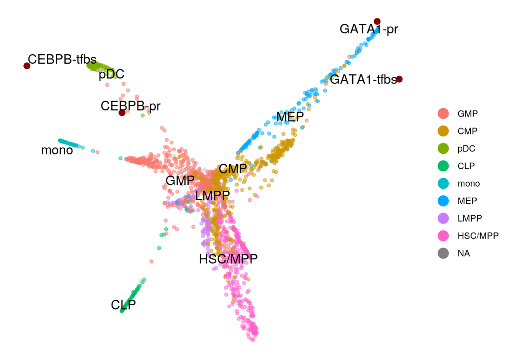

```r
swne.emb <- EmbedTFBS(swne.emb, cisTopicObject, motif_ix_mat = motif_ix_mat, genes.embed = tfs.embed, n_pull = 3,
                      overwrite = F)

plot.seed <- 512223535
PlotSWNE(swne.emb, sample.groups = clusters, pt.size = 1.25, alpha = 0.5,
         do.label = T, seed = plot.seed)
```